# Extract BCG Effectiveness at Preventing Active Disease

```r
library(tidyverse)
library(idmodelr)
library(knitr)
library(broom)
```

BCG effectiveness at preventing active disease is extrapolated from several sources for both vaccination at birth and vaccination at school-age.

# Vaccine Effecetiveness after Vaccination at School-Age

For vaccination 10-15, 15-20, 20-25, and 25-29 years ago vaccine effectivness is based on values estimated in [this](https://academic.oup.com/ije/article/47/1/193/4098108) study. As this study did not provide estimates for vaccination within 10 years the [original MRC trial](http://www.bmj.com/content/2/6082/293) of the BCG vaccine was used to provide estimates. A log normal distribution has been assumed, extrapolated from the reported risk ratio point estimates with 95% confidence intervals. The MRC trial only provided point estimates for the effectiveness of the BCG vaccine. Risk ratios have been re-estimated from the reported data using Poisson regression for those vaccinationed within 5 years and for those vaccinated within 10 years.[@Sterne1998] Updated estimates were then validated against previous published point estimates.

1. Get raw data from MRC and estimate risk ratios

```r
mrc_data <- tibble(
  cases = c(160, 67),
  vac_status = "unvaccinated",
  age = c("0-4","5-9")
) %>%
  bind_rows(
    tibble(
      cases = c(27, 22),
      vac_status = "vaccinated",
      age = c("0-4","5-9")
    )
  ) %>%
  left_join(
    tibble(vac_status = c("unvaccinated", "vaccinated"),
           population = c(12867, 13598))
  ) %>%
  mutate(vac_status = vac_status %>%
           factor(levels = c("unvaccinated", "vaccinated")))
```

```r
mrc_rr <- mrc_data %>%
  group_by(age) %>%
  nest() %>%
  mutate(model = map(data, ~ glm(cases ~ vac_status + offset(log(population)), family = poisson, data = .))) %>%
  mutate(output = map(model, ~ tidy(., exponentiate = TRUE, conf.int = TRUE, conf.level = 0.95))) %>%
  mutate(output = map(output, ~ slice(., 2))) %>%
  unnest(output) %>%
  dplyr::select(-std.error, -statistic, -p.value, -data, -model, -term) %>%
  mutate_if(is.numeric, ~round(., 2)) %>%
  mutate(source = "MRC")
```

1. Get risk ratio data from the IJE paper.

```r
ije_rr <- tibble(
  age = c("10-14", "15-19", "20-24", "25-29"),
  estimate = c(0.44, 0.43, 0.75, 0.79),
  conf.low = c(0.28, 0.29, 0.52, 0.45),
  conf.high = c(0.67, 0.64, 1.1, 1.39),
  source = "IJE"
)
```

1. Combine all risk ratios.

```r
all_rr <- mrc_rr %>%
  bind_rows(ije_rr)
```

1. Estimated effectiveness.

```r
eff_bcg <- all_rr %>%
  mutate_if(is.numeric, ~ (1 - .) * 100) %>%
  mutate(pretty_eff = paste0(estimate, " (", conf.high, ", ", conf.low, ")")) %>%
  dplyr::select(`Time since vaccination (years)` = age, `Effectiveness (%)` = pretty_eff)

eff_bcg
```

```
## # A tibble: 6 x 2
##   `Time since vaccination (years)` `Effectiveness (%)`
##   <chr>                            <chr>
## 1 0-4                              84 (76, 90)
## 2 5-9                              69 (51, 81)
## 3 10-14                            56 (33, 72)
## 4 15-19                            57 (36, 71)
## 5 20-24                            25 (-10, 48)
## 6 25-29                            21 (-39, 55)
```

```r
devtools::use_data(eff_bcg, overwrite = TRUE)
```

```
## ✔ Setting active project to '/home/ModelTBBCGEngland/ModelTBBCGEngland'
## ✔ Saving 'eff_bcg' to 'data/eff_bcg.rda'
```

```r
 #' Add as raw csv
write_csv(eff_bcg, "data-proc/eff_bcg.csv")
```

1. Plot vaccine effectivieness over time

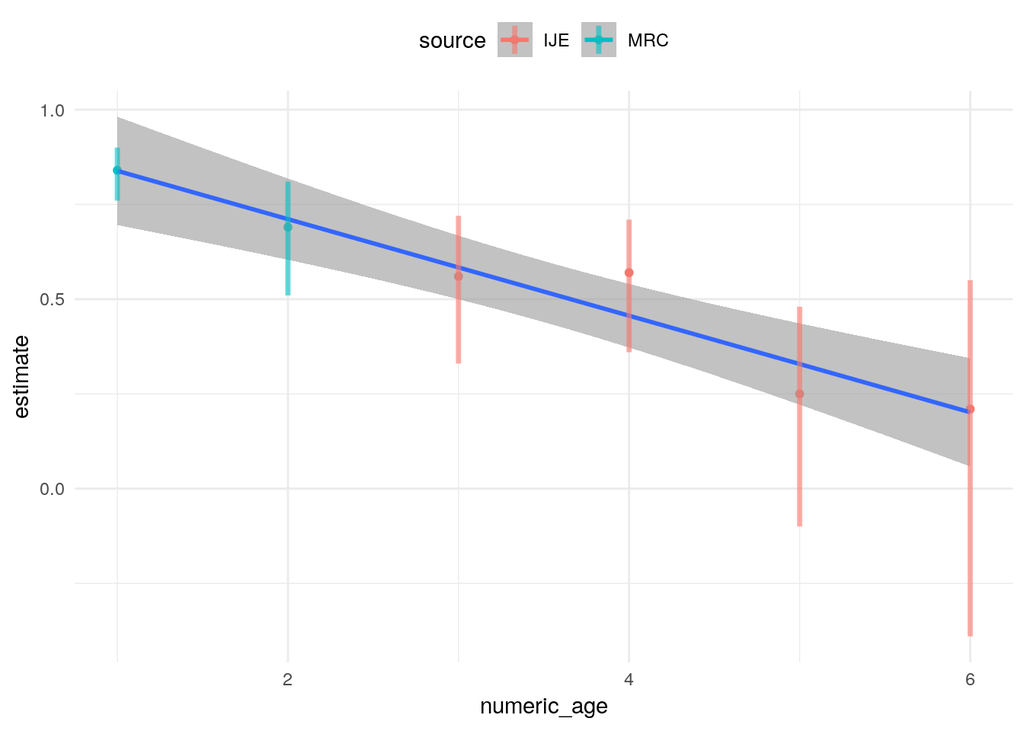

```r
all_rr %>%
  mutate_if(is.numeric, ~ (1 - .)) %>%
  mutate(age = factor(age, levels = all_rr$age)) %>%
  mutate(numeric_age = as.numeric(age)) %>%
  ggplot(aes(x = numeric_age, y = estimate, ymin = conf.low, ymax = conf.high, col = source)) +
  geom_point(size = 1.4) +
  geom_smooth(method = "lm", se = TRUE, aes(group = 1), alpha = 0.6) +
  geom_linerange(size = 1.2, alpha = 0.6) +
  theme_minimal() +
  theme(legend.position = "top") +
  guides(fill = FALSE)
```

1. Estimate the logged distribution.

```r
log_rr_bcg <- all_rr %>%
  mutate(log_mean = estimate_norm_dist_from_ci(log(conf.low), log(conf.high))$mean,
         log_sd = estimate_norm_dist_from_ci(log(conf.low), log(conf.high))$sd) %>%
  mutate_at(vars(log_mean, log_sd), ~ signif(., 4)) %>%
  mutate(log_dist = paste0("(", log_mean, ", ", log_sd, ")"))

log_rr_bcg
```

```
## # A tibble: 6 x 8
##   age   estimate conf.low conf.high source log_mean log_sd log_dist
##   <chr>    <dbl>    <dbl>     <dbl> <chr>     <dbl>  <dbl> <chr>
## 1 0-4       0.16    0.1        0.24 MRC      -1.86   0.223 (-1.865, 0.2233)
## 2 5-9       0.31    0.19       0.49 MRC      -1.19   0.242 (-1.187, 0.2417)
## 3 10-14     0.44    0.28       0.67 IJE      -0.837  0.223 (-0.8367, 0.222…
## 4 15-19     0.43    0.290      0.64 IJE      -0.842  0.202 (-0.8421, 0.201…
## 5 20-24     0.75    0.52       1.1  IJE      -0.279  0.191 (-0.2793, 0.191…
## 6 25-29     0.79    0.45       1.39 IJE      -0.235  0.288 (-0.2346, 0.287…
```

```r
devtools::use_data(log_rr_bcg, overwrite = TRUE)
```

```
## ✔ Saving 'log_rr_bcg' to 'data/log_rr_bcg.rda'
```

```r
 #' Add as raw csv
write_csv(log_rr_bcg, "data-proc/log_rr_bcg.csv")
```

```r
sampled_eff <- log_rr_bcg %>%
  group_by(age) %>%
  mutate(sample = list(rnorm(1e4, mean = log_mean, sd = log_sd)),
         exp_sample = map(sample, exp),
         point_rr = map(exp_sample, mean),
         point_eff = map(point_rr, ~ 1 - .))

sampled_eff %>%
  unnest(point_eff) %>%
  dplyr::select(age, point_eff) %>%
  mutate(point_eff = round(point_eff * 100, 1)) %>%
  left_join(eff_bcg, by = c("age" = "Time since vaccination (years)"))
```

```
## # A tibble: 6 x 3
## # Groups:   age [?]
##   age   point_eff `Effectiveness (%)`
##   <chr>     <dbl> <chr>
## 1 0-4        84.1 84 (76, 90)
## 2 5-9        68.6 69 (51, 81)
## 3 10-14      55.8 56 (33, 72)
## 4 15-19      56.1 57 (36, 71)
## 5 20-24      23.1 25 (-10, 48)
## 6 25-29      17.6 21 (-39, 55)
```

```r
est_bcg_alpha_decay <- sampled_eff %>%
  mutate(sample = map(exp_sample, ~ tibble(sample = 1:length(.), value = 1 - .))) %>%
  dplyr::select(age, estimate, sample) %>%
  unnest %>%
  dplyr::mutate(age_numeric = age %>%
           factor(levels = sampled_eff$age %>% unique) %>%
           as.numeric() %>%
           {. - 1}) %>%
  ungroup %>%
  group_by(sample) %>%
  nest() %>%
  mutate(model = map(data, ~ lm(value ~ age_numeric, data = .)),
         decay = map(model, ~ broom::tidy(.) %>%
                        select(term, estimate, std.error) %>%
                        filter(term == "age_numeric") %>%
                        {tibble(estimate = rnorm(1e4, .$estimate, .$std.error), sub_sample = 1:nrow(.))} %>%
                        select(estimate, sub_sample))) %>%
  dplyr::select(sample, data, decay) %>%
  unnest(decay) %>%
  ungroup %>%
  summarise(mean_decay = mean(estimate), sd_decay = sd(estimate)) %>%
  mutate_all(~ signif(., digits = 4))

est_bcg_alpha_decay
```

```
## # A tibble: 1 x 2
##   mean_decay sd_decay
##        <dbl>    <dbl>
## 1     -0.134   0.0516
```

```r
usethis::use_data(est_bcg_alpha_decay, overwrite = TRUE)
```

```
## ✔ Saving 'est_bcg_alpha_decay' to 'data/est_bcg_alpha_decay.rda'
```

```r
 #' Add as raw csv
write_csv(est_bcg_alpha_decay, "data-proc/est_bcg_alpha_decay.csv")
```

1. Test by sampling from the initial effectivness and decay paramters

```r
test_decay <- tibble(initial_eff = 1 - exp(rnorm(1e5, mean = log_rr_bcg$log_mean[[1]], sd = log_rr_bcg$log_sd[[1]])),
                     decay = rnorm(1e5, mean = est_bcg_alpha_decay$mean_decay[[1]], sd = est_bcg_alpha_decay$sd_decay[[1]])) %>%
  mutate(id = 1) %>%
  full_join(tibble(age_numeric = 0:5, id = 1), by = "id") %>%
  select(-id) %>%
  mutate(est_eff = initial_eff + decay * age_numeric) %>%
  group_by(age_numeric) %>%
  summarise(estimate = mean(est_eff), sd = sd(est_eff)) %>%
  mutate(conf.high = estimate + 1.96 * sd, conf.low = estimate - 1.96 * sd) %>%
  select(-sd, - age_numeric) %>%
  mutate(age = all_rr$age) %>%
  mutate(source = "Linear estimate")

test_decay
```

```
## # A tibble: 6 x 5
##   estimate conf.high conf.low age   source
##      <dbl>     <dbl>    <dbl> <chr> <chr>
## 1    0.841     0.912    0.771 0-4   Linear estimate
## 2    0.707     0.830    0.584 5-9   Linear estimate
## 3    0.573     0.787    0.359 10-14 Linear estimate
## 4    0.439     0.750    0.128 15-19 Linear estimate
## 5    0.305     0.715   -0.105 20-24 Linear estimate
## 6    0.171     0.681   -0.339 25-29 Linear estimate
```

1. Plot actual and decay estimated data

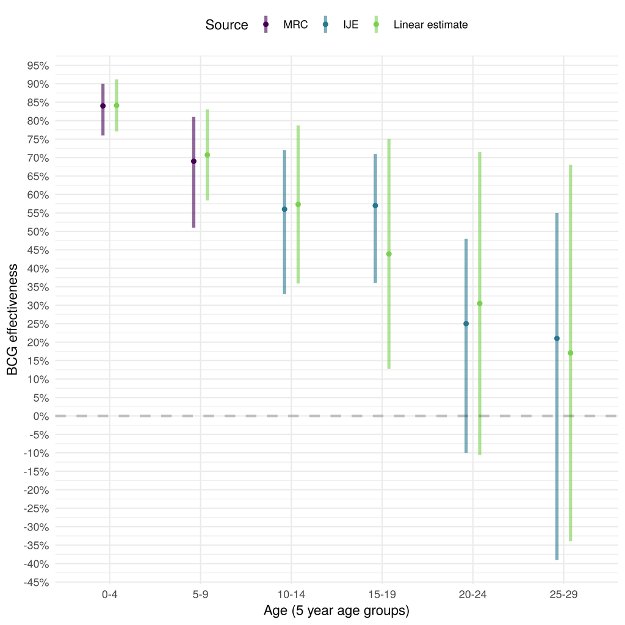

```r
all_rr %>%
  mutate_if(is.numeric, ~ (1 - .)) %>%
  bind_rows(test_decay) %>%
  mutate(age = factor(age, levels = all_rr$age),
         source = factor(source, levels = unique(.$source)))  %>%
  ggplot(aes(x = age, y = estimate, ymin = conf.low, ymax = conf.high, col = source)) +
  geom_point(size = 1.4, position = position_dodge(width = 0.3)) +
  geom_linerange(size = 1.2, alpha = 0.6, position = position_dodge(width = 0.3)) +
  scale_color_viridis_d(end = 0.8) +
  scale_y_continuous(labels = scales::percent, breaks = seq(-0.5, 1, 0.05)) +
  geom_hline(yintercept = 0, linetype = 2, size = 1, alpha = 0.2) +
  theme_minimal() +
  guides(col = guide_legend(title = "Source")) +
  theme(legend.position = "top") +
  labs(x = "Age (5 year age groups)", y = "BCG effectiveness")
```

```r
ggsave("figure/est_bcg_alpha.png", dpi = 330)
```

[output not shown]